# Gozde and Liora Replication Code

Gozde Guran and Liora Goldensher

3/6/2015

# Replication Code for “Contextual Factors and the Extreme Right Vote in Europe, 1980-2002” by Kai Arzheimer American Journal of Political Science (2009)

Note: Please refer to saved files in our repository for images from the article. Also please refer to the table and figures (Table 1, Figure 1, 2) in the repository. Image scales are rearranged in saved versions. Our regression values are slightly different from the authors as his stata code used a slightly different method than our function (glmmPQL) to calculate Penalized Quasi-likehood. Finally, we were not able to reproduce the last two figures that showed the joint impact of more than 2 variables; we’ll keep working on these.

# The paper

Kai Arzheimer, “Contextual Factors and the Extreme Right Vote in Western Europe, 1980-2002”25548117.pdf This article attempts to answer the “twin question of why the extreme right support is so unstable within many countries over time, and why these parties are so weak in many West European countries.” Authors conduct a multi-level analysis, combining data on macro-level contextual variables (unemployment, immigration, and welfare benefits) with individual-level variables (sociodemographic factors and attitudes).

# The data

Individual-level variables come from Eurobarometer surveys (1980-2002), while contextual variables are gathered from a number of different data sets produced by the OECD, UNHCR etc. The merged data and the Stata code are available through the author’s dataverse at: http://hdl.handle.net/1902.1/12092.

# The model

The article uses a logistic multi-level model via Penalized Quasi-Likelihood. The dependent variable is vote intention for an extreme right party, which is assumed to be binomially distributed.

# Run necessary packages and load data (Source: Arzheimer dataverse)

```r
library(MASS)
library(nlme)
library(xtable)
library(foreign)
library(dplyr)
```

```r
library(broom)
library(ggplot2)
library(xtable)
library(stargazer)
library(grid)
library(gridExtra)

data <- read.dta("nonimp.dta")

# Cleaning up data
data <- rename(data, ext_vote = rexvote)
data <- rename(data, age_1 = age1) # (18–29 years)
data <- rename(data, age_2 = age2) # (30–45 years)
data <- rename(data, age_4 = age4) # (>65 years)
data <- rename(data, edu_1 = mye1) # Education: middle/high
data <- rename(data, edu_2 = mye2) # Education: university
data <- rename(data, farmer_own = farmerown)
data <- rename(data, left_right_scale = zlrs) # Left-Right Scale
data <- rename(data, eu_neg = euschlecht) # Negative evaluation of EU membership of one's own country
data <- rename(data, z_dem_satis = zsatisdmo) # Dissatisfied: Democracy
data <- rename(data, dispro_elect = disp) # Disproportionality
data <- rename(data, federalism = lfed1) # Decentralization
data <- rename(data, z_asylumseeker = zasylumseekers)
data <- rename(data, z_unemp = zsur) # Unemployment rate
data <- rename(data, z_replacement = zreplacementrate) # Unemp benefits
data <- rename(data, max_er = rmax) # Maximum toughness in extreme right discourse
```

# Preparing data for analysis

```r
# Create centered variables for Saliance and Variance based on grand mean centering according to author

data <- data  %>%
  mutate(salience_mean_c = (salienzmean - 3.84568)) %>%
  mutate(var_c = rvar - 21.75423)

# Make male variable numeric
data <- data %>%
  mutate(male = as.numeric(male))

# Create a dummy variable for country (transform from character to factor variable)
data <- data %>%
  mutate(country = factor(sortcountry, labels = c("AT", "BE","DE-E","DE-W","DK","ES","FI","FR","GR","IT","LU","NL","NO","PT","SE")))
```

# Run the regression (multilevel logictic regression based on Quasi-penalized likelihood): All contextual variables are standardized mean-centered (as connoted by “z-”)

```r
model <- glmmPQL(ext_vote ~ male + age_1 + age_2 + age_4 + edu_1 + edu_2 + farmer_own + worker + retired + unemployed + left_right_scale + eu_neg + z_dem_satis + dispro_elect + federalism + z_asylumseeker + z_unemp + z_asylumseeker:z_unemp + z_replacement + z_replacement:z_unemp + z_replacement:z_asylumseeker + max_er + salience_mean_c + var_c + var_c:salience_mean_c + country - 1, random = ~1|kontext, family = binomial(link = "logit"), data = data, verbose = TRUE)
```

```
## iteration 1
## iteration 2
## iteration 3
## iteration 4
```

```r
# summary(model) # Output too long
```

# Table 1

```r
# Create vectors of coefficients, standard deviations, and variable names

coefficient <- as.vector(model$coef$fixed)
n <- c(174452, 267)
stand_dev <- as.vector(sqrt(diag(model$varFix)))

# Create matrix of coefficients and standard deviations.

table_matrix <- cbind(coefficient, stand_dev)

# Label matrix.

rownames(table_matrix) <- c("Male","18_29 years","30_45 years",">65 years","Education: middle/high","Education: university","Petty Bourgeoisie","Worker","Pensioner","Unemployed","Left-Right","Dissatisfied: EU","Dissatisfied: Democracy","Disproportionality","Decentralization","Asylumseekers", "Unemployment", "Asylumseekers x Unemployment", "Toughness", "Salience", "Variance", "AT", "BE", "DE-E", "DE-W", "DK", "ES", "FI", "FR", "GR", "IT", "NL", "NO", "PT", "SE", "Asylumseekers x Unemployment", "Unemployment benefits x Unemployment", "Unemployment benefits x Asylumseekers", "Variance x Salience")

# Create Table 1 with stargaze

table_1 <- stargazer(table_matrix, title = "TABLE 1 Support for the Extreme Right: Sociodemographics, Attitudes, Country Effects, and Contextual Variables", align = TRUE, table.layout = "t", notes = "Logistic multilevel model. PQL2 estimates and model-based standard errors.", style = "ajps", out = "Table 1.html", no.space = TRUE)
```

```
##
## % Table created by stargazer v.5.1 by Marek Hlavac, Harvard University. E-mail: hlavac at fas.harvard.edu
## % Date and time: Mon, Mar 16, 2015 - 12:47:21 AM
## % Requires LaTeX packages: dcolumn
## \begin{table}[!htbp] \centering
##   \caption{TABLE 1 Support for the Extreme Right: Sociodemographics, Attitudes, Country Effects, and Contextual Variables}
##   \label{}
## \begin{tabular}{@{\extracolsep{5pt}} D{.}{.}{-3} D{.}{.}{-3} D{.}{.}{-3} }
## \\[-1.8ex]\hline \\[-1.8ex]
## \multicolumn{1}{c}{} & \multicolumn{1}{c}{coefficient} & \multicolumn{1}{c}{stand\_dev} \\
## \hline \\[-1.8ex]
## \multicolumn{1}{c}{Male} & 0.478 & 0.030 \\
## \multicolumn{1}{c}{18\_29 years} & 0.433 & 0.044 \\
## \multicolumn{1}{c}{30\_45 years} & 0.192 & 0.041 \\
## \multicolumn{1}{c}{\textgreater 65 years} & -0.160 & 0.057 \\
## \multicolumn{1}{c}{Education: middle/high} & 0.056 & 0.038 \\
## \multicolumn{1}{c}{Education: university} & -0.321 & 0.045 \\
## \multicolumn{1}{c}{Petty Bourgeoisie} & 0.043 & 0.051 \\
## \multicolumn{1}{c}{Worker} & 0.367 & 0.042 \\
## \multicolumn{1}{c}{Pensioner} & 0.054 & 0.055 \\
## \multicolumn{1}{c}{Unemployed} & 0.466 & 0.060 \\
## \multicolumn{1}{c}{Left-Right} & 0.549 & 0.007 \\
## \multicolumn{1}{c}{Dissatisfied: EU} & 0.745 & 0.038 \\
## \multicolumn{1}{c}{Dissatisfied: Democracy} & 0.603 & 0.019 \\
## \multicolumn{1}{c}{Disproportionality} & 0.011 & 0.015 \\
## \multicolumn{1}{c}{Decentralization} & 0.156 & 0.154 \\
## \multicolumn{1}{c}{Asylumseekers} & 0.240 & 0.055 \\
## \multicolumn{1}{c}{Unemployment} & 0.080 & 0.032 \\
## \multicolumn{1}{c}{Asylumseekers x Unemployment} & 0.014 & 0.009 \\
## \multicolumn{1}{c}{Toughness} & -0.039 & 0.023 \\
## \multicolumn{1}{c}{Salience} & 0.119 & 0.025 \\
## \multicolumn{1}{c}{Variance} & 0.007 & 0.007 \\
## \multicolumn{1}{c}{AT} & -3.704 & 0.719 \\
## \multicolumn{1}{c}{BE} & -5.905 & 0.649 \\
## \multicolumn{1}{c}{DE-E} & -7.457 & 0.734 \\
## \multicolumn{1}{c}{DE-W} & -6.858 & 0.745 \\
## \multicolumn{1}{c}{DK} & -5.428 & 0.422 \\
## \multicolumn{1}{c}{ES} & -9.013 & 0.513 \\
## \multicolumn{1}{c}{FI} & -7.726 & 0.433 \\
## \multicolumn{1}{c}{FR} & -5.230 & 0.347 \\
## \multicolumn{1}{c}{GR} & -5.933 & 0.358 \\
## \multicolumn{1}{c}{IT} & -3.668 & 0.330 \\
## \multicolumn{1}{c}{NL} & -7.831 & 0.430 \\
## \multicolumn{1}{c}{NO} & -5.618 & 0.427 \\
## \multicolumn{1}{c}{PT} & -6.646 & 0.429 \\
## \multicolumn{1}{c}{SE} & -8.160 & 0.588 \\
## \multicolumn{1}{c}{Asylumseekers x Unemployment} & -0.024 & 0.014 \\
## \multicolumn{1}{c}{Unemployment benefits x Unemployment} & -0.002 & 0.002 \\
## \multicolumn{1}{c}{Unemployment benefits x Asylumseekers} & -0.010 & 0.005 \\
## \multicolumn{1}{c}{Variance x Salience} & -0.001 & 0.0003 \\
## \hline \\[-1.8ex]
## \multicolumn{3}{l}{Logistic multilevel model. PQL2 estimates and model-based standard errors.} \\
## \end{tabular}
## \end{table}
```

# Figure 1 (Conditonal Effects of Unemployment and Immigration)

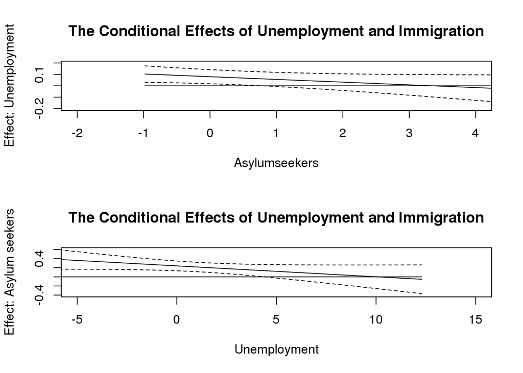

```r
library(msm)
asy <- seq(from = -.98, to = 4.46, by = .01) # vector with possible values for asylumseekers
variable <- asy # to standardize the code
slopes <- model$coef$fixed[17] + model$coef$fixed[36] * asy # Estimated slopes based on estimated coefficients of unemployment (17) and unemployment x immigration (36)
estmean <- model$coef$fixed # Estimated means for each variable
var <- vcov(model) # Estimated variances
se <- rep(NA, length(asy))

for (i in 1:length(variable)) {
  j <- variable[i]
  se[i] <- deltamethod (~ (x17) + (x36) * j, estmean, var)
}
# Create confidence intervals and combine all values in matrix.
upper <- slopes + 1.96 * se
lower <- slopes - 1.96 * se
variable.data <- cbind(variable, slopes, upper, lower)

# Creating the first graph in base R
par(mfrow = c(2, 1))
plot(variable, slopes, type = "l", lty = 1, ylim = c(-.2, .2), xlim = c(-2, 4), ylab = "Effect: Unemployment", xlab = "Asylumseekers", main = "The Conditional Effects of Unemployment and Immigration")
points(variable, upper, type = "l", lty = 2)
points(variable, lower, type = "l", lty = 2)
points(variable, rep(0, length(variable)), type = "l", col = "black")

# Creating the same graph with ggplot - much better looking.

variable.data <- data.frame(variable.data) # Turn matrix into data frame so that ggplot can read it.
xtitle <- "Asylumseekers"
ytitle <- "Effect: Unemployment"
main <- "Figure 1: The Conditional Effects of Unemployment and Immigration"
graph_1 <- ggplot(variable.data, aes(x = variable, y = slopes)) +
  geom_line(aes(y = slopes), color = "blue") +
  geom_ribbon(aes(ymin = lower, ymax = upper), alpha = 0.2) +
  geom_hline(yintercept = 0, size = 0.4, color = "black") +
  labs(x = xtitle, y = ytitle, title = main) +
  coord_fixed(ratio = 8)

#Figure 1, graph 2

unemployment <- seq(from = -5.908098, to = 12.291902, by = .01) # vector with possible values for unemployment
variable <- unemployment
slopes <- model$coef$fixed[16] + model$coef$fixed[36] * variable # Estimated slopes based on estimated coefficients of unemployment (16) and unemployment x immigration (36)
estmean <- model$coef$fixed # Estimated means for each variable
var <- vcov(model)
se <- rep(NA, length(variable))

for (i in 1:length(variable)) {
  j <- variable[i]
  se[i] <- deltamethod (~ (x16) + (x36) * j, estmean, var)
}
# Create confidence intervals and combine all values in matrix.
upper <- slopes + 1.96 * se
lower <- slopes - 1.96 * se
variable.data <- cbind(variable, slopes, upper, lower)

# Creating second part of the figure in base R

plot(variable, slopes, type = "l", lty = 1, ylim=c(-.4, .6), xlim=c(-5, 15), ylab= "Effect: Asylum seekers", xlab = "Unemployment", main = "The Conditional Effects of Unemployment and Immigration")
points(variable, upper, type = "l", lty = 2)
points(variable, lower, type = "l", lty = 2)
points(variable, rep(0, length(variable)), type = "l", col = "black")
```

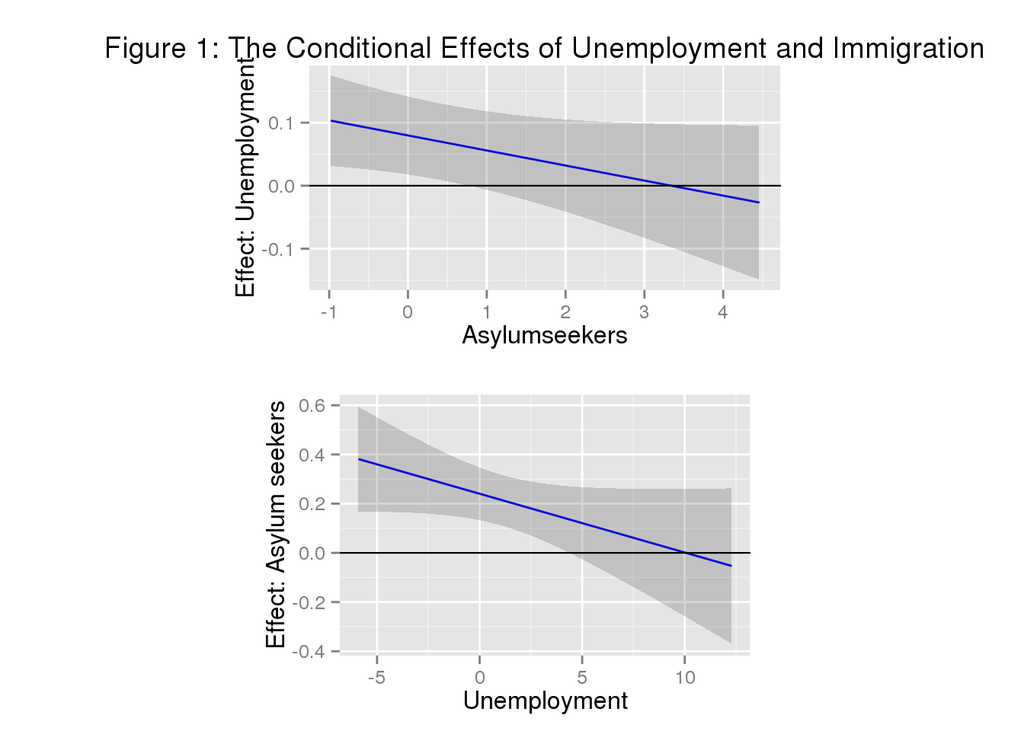

```r
# Creating the same graph with ggplot:

variable.data <- data.frame(variable.data) # Turn matrix into data frame so that ggplot can read it.
xtitle <- "Unemployment"
ytitle <- "Effect: Asylum seekers"
main <- "The Conditional Effects of Unemployment and Immigration"
graph_2 <- ggplot(variable.data, aes(x = variable, y = slopes)) +
  geom_line(aes(y = slopes), color = "blue") +
  geom_ribbon(aes(ymin = lower, ymax = upper), alpha = 0.2) +
  geom_hline(yintercept = 0, size = 0.4, color = "black") +
  labs(x = xtitle, y = ytitle) +
  coord_fixed(ratio = 12)

# Figure 1 with ggplot

grid.arrange(graph_1, graph_2, ncol = 1)
```

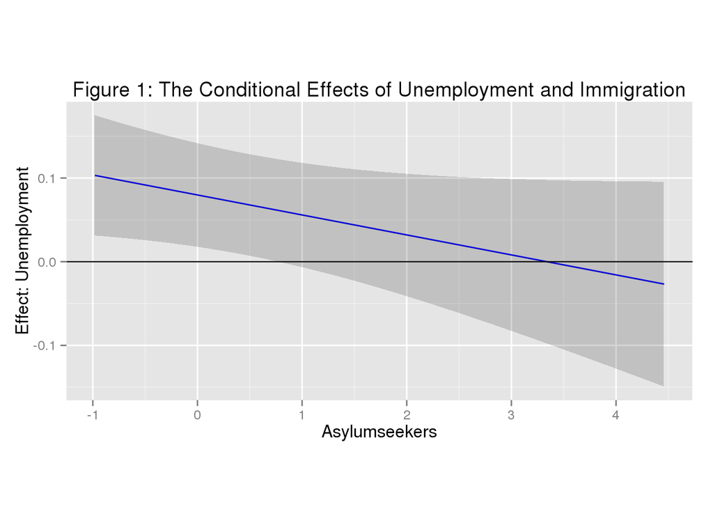

```r
# Plot separately - better scaled
graph_1
```

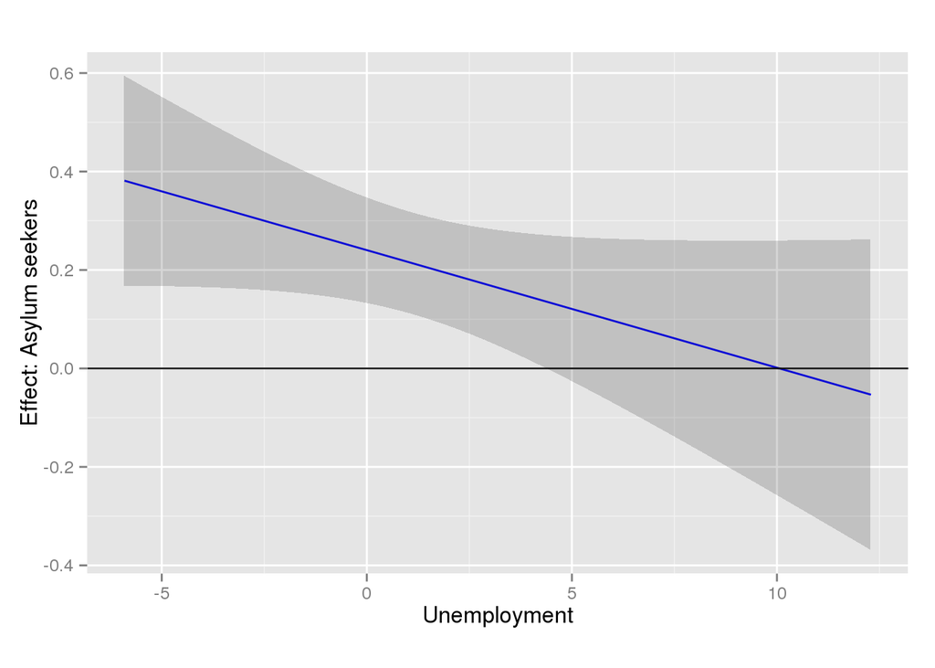

```r
graph_2
```

# Figure 2 (Conditonal Effects of Salience and Variance)

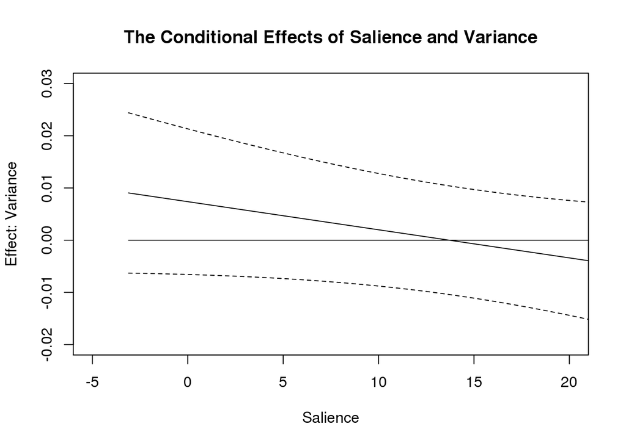

```r
# Graph 1
salience <- seq(from = -3.108026, to = 21.872906, by=.1) # vector with possible values for salience
variable <- salience
slopes <- model$coef$fixed[21] + model$coef$fixed[39] * variable # Estimated slopes based on estimated coefficients of salience (21) and salience x variance (39)
estmean <- model$coef$fixed # Estimated means for each variable
var <- vcov(model)
se <- rep(NA, length(variable))

for (i in 1:length(variable)) {
  j <- variable[i]
  se[i] <- deltamethod (~ (x21) + (x39)*j, estmean, var)
}
# Create confidence intervals and combine all values in matrix.
upper <- slopes + 1.96*se
lower <- slopes - 1.96*se
variable.data <- cbind(variable, slopes, upper, lower)


# Creating the first graph in base R

plot(variable, slopes, type = "l", lty = 1, ylim=c(-.02, .03), xlim=c(-5, 20), ylab= "Effect: Variance", xlab = "Salience", main = "The Conditional Effects of Salience and Variance")
points(variable, upper, type = "l", lty = 2)
points(variable, lower, type = "l", lty = 2)
points(variable, rep(0, length(variable)), type = "l", col = "black")
```

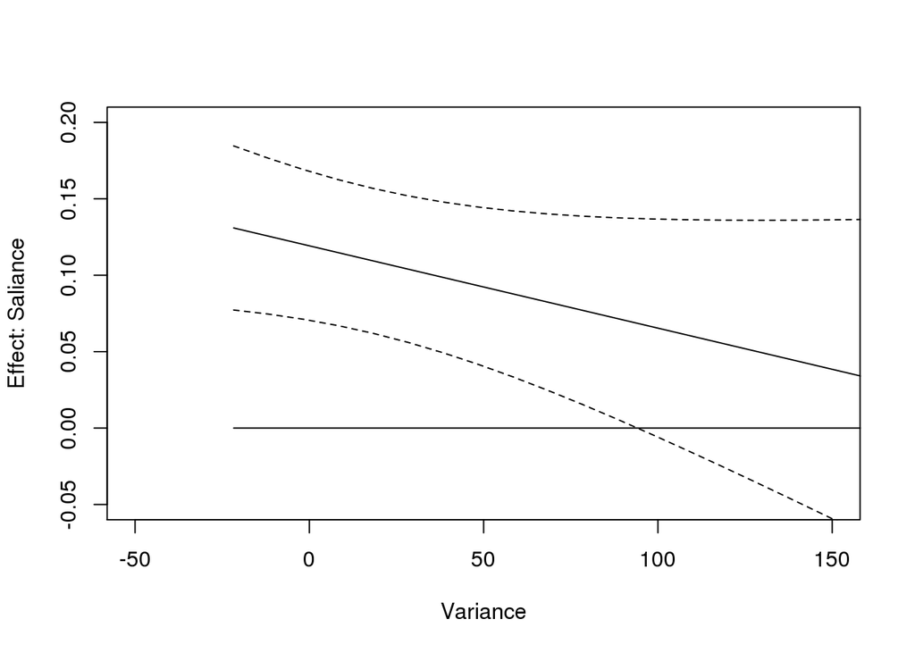

```r
# Creating the same graph with ggplot:

variable.data <- data.frame(variable.data) # Turn matrix into data frame so that ggplot can read it.
xtitle <- "Salience"
ytitle <- "Effect: Variance"
main <- "The Conditional Effects of Salience and Variance"
graph_3 <- ggplot(variable.data, aes(x = variable, y = slopes)) +
  geom_line(aes(y = slopes), color = "blue") +
  geom_ribbon(aes(ymin = lower, ymax = upper), alpha = 0.2) +
  geom_hline(yintercept = 0, size = 0.4, color = "black") +
  labs(x = xtitle, y = ytitle, title = main) +
  coord_fixed(ratio = 400)

# Second part of Figure 2:

variance <- seq(from = -21.71426, to = 174.34497, by=10) # vector with possible values for variance
variable <- variance
slopes <- model$coef$fixed[20] + model$coef$fixed[39] * variable # Estimated slopes based on estimated coefficients of salience (20) and salience x variance (39)
se <- rep(NA, length(variable))
for (i in 1:length(variable)) {
  j <- variable[i]
  se[i] <- deltamethod (~ (x20) + (x39) * j, estmean, var)
}
# Create confidence intervals and combine all values in matrix.
upper <- slopes + 1.96 * se
lower <- slopes - 1.96 * se
variable.data <- cbind(variable, slopes, upper, lower)

# Creating the second graph in base R
par(mfrow = c(1,1))
plot(variable, slopes, type = "l", lty = 1, ylim = c(-.05, .2), xlim = c(-50, 150), ylab = "Effect: Saliance", xlab = "Variance")
points(variable, upper, type = "l", lty = 2)
points(variable, lower, type = "l", lty = 2)
points(variable, rep(0, length(variable)), type = "l", col = "black")
```

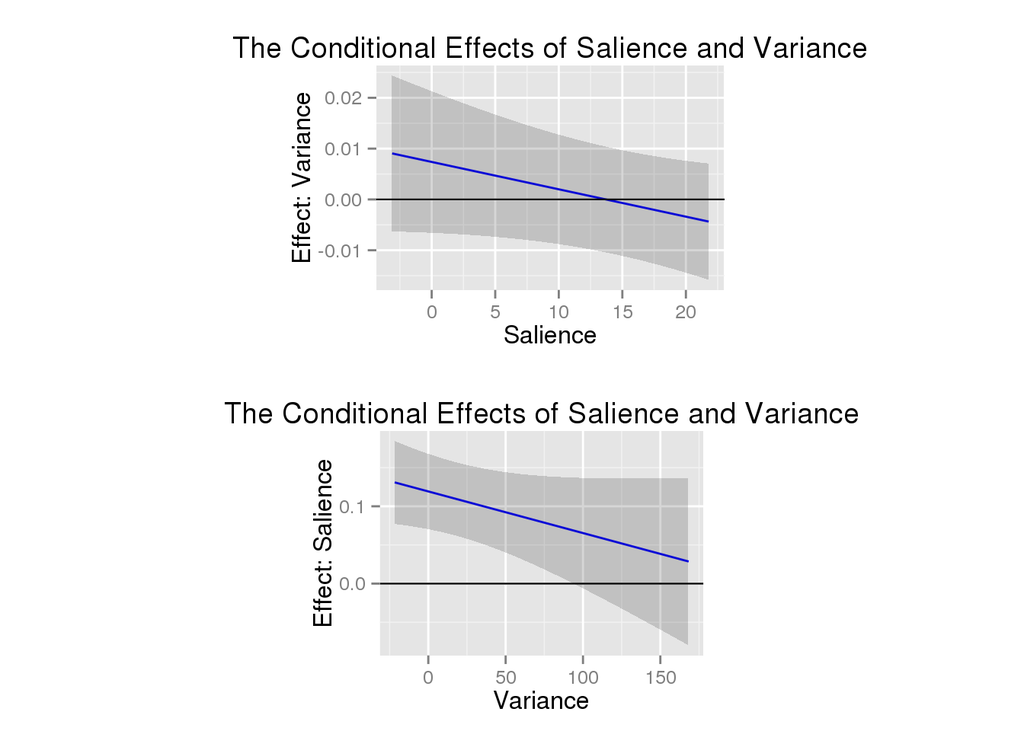

```r
# Creating the same graph with ggplot:

variable.data <- data.frame(variable.data) # Turn matrix into data frame so that ggplot can read it.
xtitle <- "Variance"
ytitle <- "Effect: Salience"
main <- "The Conditional Effects of Salience and Variance"
graph_4 <- ggplot(variable.data, aes(x = variable, y = slopes)) +
  geom_line(aes(y = slopes), color = "blue") +
  geom_ribbon(aes(ymin = lower, ymax = upper), alpha = 0.2) +
  geom_hline(yintercept = 0, size = 0.4, color = "black") +
  labs(x = xtitle, y = ytitle, title = main) +
  coord_fixed(ratio = 500)

grid.arrange(graph_3, graph_4, ncol = 1)
```

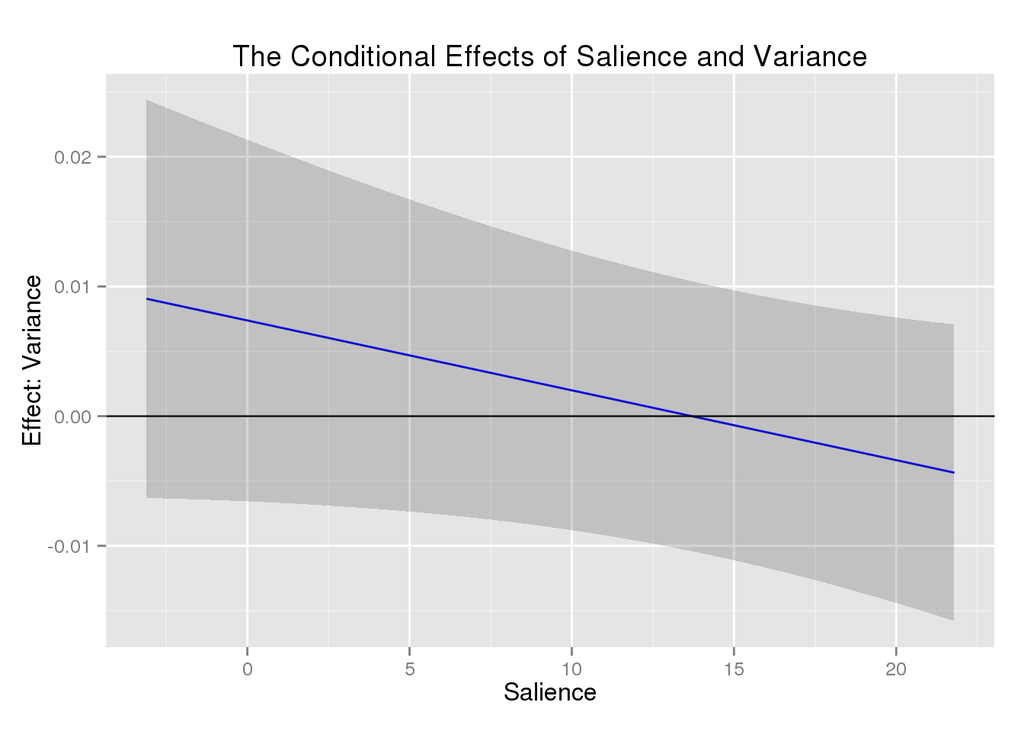

```r
# Better scaled versions - not combined
graph_3
```

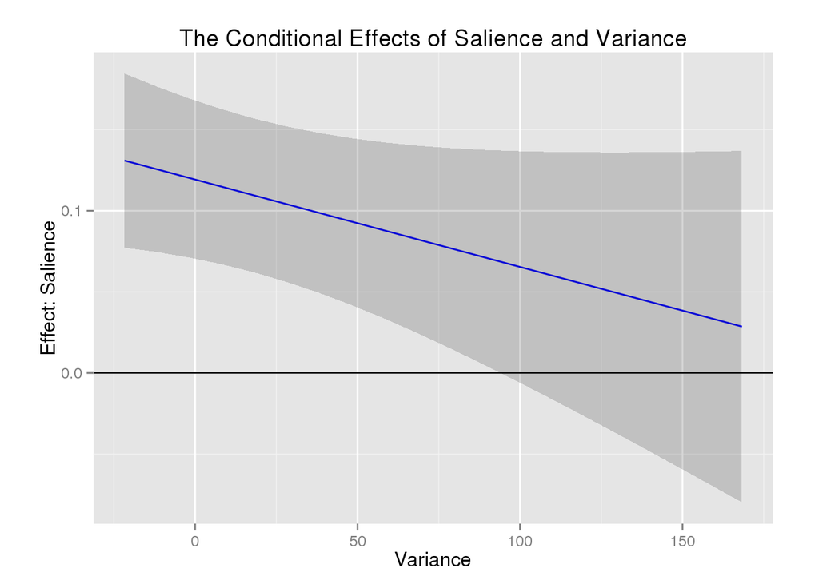

```r
graph_4
```